# Data Science With R-Project Healthcare - Simplilearn

Dheeraj Bharat Sethi

8/1/2020

# Project Statement

A nationwide survey of hospital costs conducted by the US Agency for Healthcare consists of hospital records of inpatient samples. The given data is restricted to the city of Wisconsin and relates to #patients in the age group 0-17 years. The agency wants to analyze the data to research on healthcare costs and their utilization.

First, lets import the required csv file, and get the feel of data, columns etc We will be using various R basic functions to do that

```r
hospital_data<-read.csv(file.choose(),header = T)
names(hospital_data) #Get the columns
```

```
## [1] "AGE"    "FEMALE" "LOS"    "RACE"   "TOTCHG" "APRDRG"
```

```r
head(hospital_data) #First 6 rows
```

|  | AGE | FEMALE | LOS | RACE | TOTCHG | APRDRG |
| --- | --- | --- | --- | --- | --- | --- |
| 1 | 17 | 1 | 2 | 1 | 2660 | 560 |
| 2 | 17 | 0 | 2 | 1 | 1689 | 753 |
| 3 | 17 | 1 | 7 | 1 | 20060 | 930 |
| 4 | 17 | 1 | 1 | 1 | 736 | 758 |
| 5 | 17 | 1 | 1 | 1 | 1194 | 754 |
| 6 | 17 | 0 | 0 | 1 | 3305 | 347 |

```r
str(hospital_data) #Structure, datatype of each column
```

```
## 'data.frame':    500 obs. of  6 variables:
##  $ AGE   : int  17 17 17 17 17 17 17 16 16 17 ...
##  $ FEMALE: int  1 0 1 1 1 0 1 1 1 1 ...
##  $ LOS   : int  2 2 7 1 1 0 4 2 1 2 ...
##  $ RACE  : int  1 1 1 1 1 1 1 1 1 1 ...
##  $ TOTCHG: int  2660 1689 20060 736 1194 3305 2205 1167 532 1363 ...
##  $ APRDRG: int  560 753 930 758 754 347 754 754 753 758 ...
```

# Task 1

To record the patient statistics, the agency wants to find the age category of people who frequent the hospital and has the maximum expenditure.

So, here we need to find out the number of records grouped by AGE As AGE is int variable, its better to convert that to a factor, and then use table, summary functions to get the count of rows based on AGE values

```r
#hospital_data$AGE<-as.factor(hospital_data$AGE)
levels(as.factor(hospital_data$AGE))
```

```
##  [1] "0"  "1"  "2"  "3"  "4"  "5"  "6"  "7"  "8"  "9"  "10" "11" "12" "13" "14"
## [16] "15" "16" "17"
```

```r
table(as.factor(hospital_data$AGE)) #here AGE 0 has max number, getting an idea
```

```
##
##   0   1   2   3   4   5   6   7   8   9  10  11  12  13  14  15  16  17
## 307  10   1   3   2   2   2   3   2   2   4   8  15  18  25  29  29  38
```

```r
summary(hospital_data) #Summary of each variable in the dataset
```

```
##       AGE             FEMALE           LOS              RACE
##  Min.   : 0.000   Min.   :0.000   Min.   : 0.000   Min.   :1.000
##  1st Qu.: 0.000   1st Qu.:0.000   1st Qu.: 2.000   1st Qu.:1.000
##  Median : 0.000   Median :1.000   Median : 2.000   Median :1.000
##  Mean   : 5.086   Mean   :0.512   Mean   : 2.828   Mean   :1.078
##  3rd Qu.:13.000   3rd Qu.:1.000   3rd Qu.: 3.000   3rd Qu.:1.000
##  Max.   :17.000   Max.   :1.000   Max.   :41.000   Max.   :6.000
##                                                    NA's   :1
##      TOTCHG          APRDRG
##  Min.   :  532   Min.   : 21.0
##  1st Qu.: 1216   1st Qu.:640.0
##  Median : 1536   Median :640.0
##  Mean   : 2774   Mean   :616.4
##  3rd Qu.: 2530   3rd Qu.:751.0
##  Max.   :48388   Max.   :952.0
##
```

```r
#Now the max cost analysis, we need the aggregated values of TOTCHRG based on AGE, we can use aggregate function
cost_aggregate<-aggregate(TOTCHG~AGE,data = hospital_data,FUN = sum)
cost_aggregate
```

| AGE | TOTCHG |
| --- | --- |
| 0 | 678118 |
| 1 | 37744 |
| 2 | 7298 |
| 3 | 30550 |
| 4 | 15992 |
| 5 | 18507 |
| 6 | 17928 |
| 7 | 10087 |
| 8 | 4741 |
| 9 | 21147 |

[output cut: 8 more lines]

```r
max(cost_aggregate) #678118
```

```
## [1] 678118
```

```r
cost_aggregate[which.max(cost_aggregate$TOTCHG),] #Tells AGE=0 as maximum entry in aggregate
```

|  | AGE | TOTCHG |
| --- | --- | --- |
| 1 | 0 | 678118 |

## Conclusion 1:

Above output clearly shows the AGE=0 has 307 records, meaning, patients with AGE=0 are the most frequent visitors to the hospital_data.

## Conclusion 2:

Aggregated expenditure of AGE=0 is the maximum, meaning, AGE=0 has the maximum costs.

Its time to PLOT these to visualize the observation We can draw a Histogram, or a BarPlot

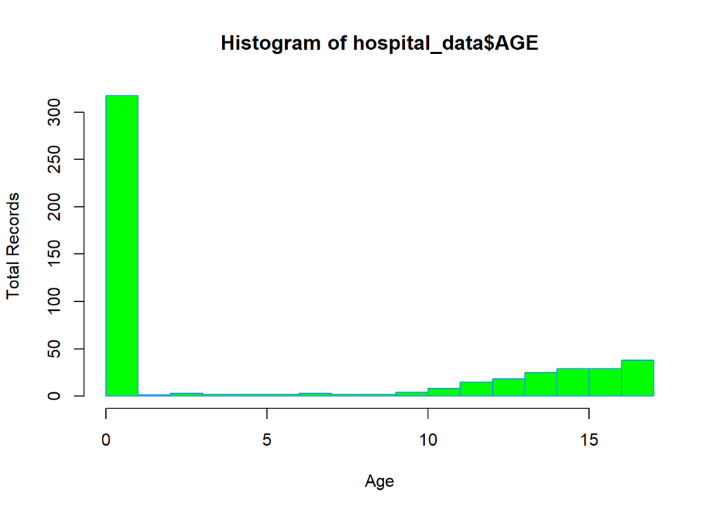

```r
hist(hospital_data$AGE,breaks = nlevels(as.factor(hospital_data$AGE)),xlab = "Age",ylab = "Total Records",col = "green",freq = T,density = 100,border = 4)
```

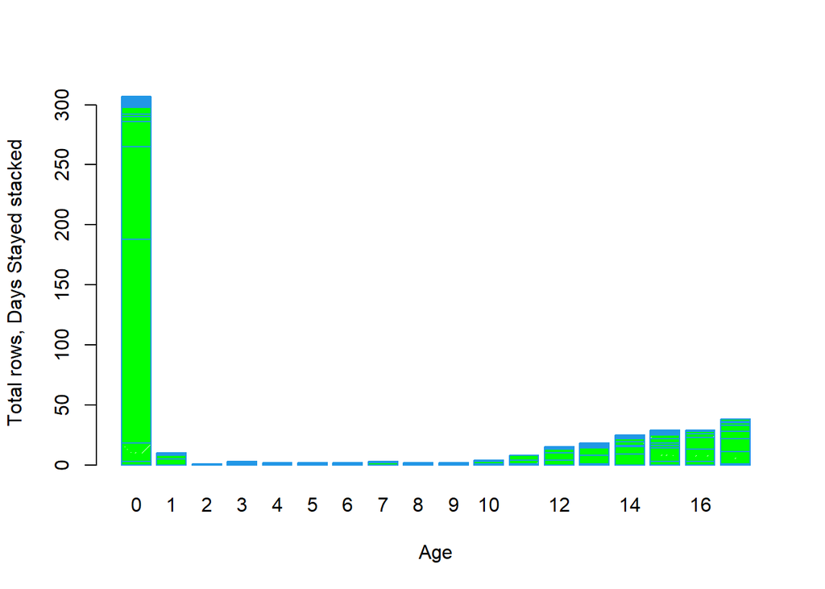

```r
barplot(table(hospital_data$LOS,hospital_data$AGE),xlab = "Age",ylab = "Total rows, Days Stayed stacked",col = "green",density = 100,border = 4)
```